# Climate and Phenology

## Phenology

- **Phenology is the study of the timing of cyclical events in an organism’s life cycle**
  - flowering of plants,
  - emergence of worker bees from the hive
  - migration of birds
- **Timing of critical life stages can be triggered by external environmental clues**
  - seasonal temperature change,
  - photo period (day length)
  - precipitation
- **An important component of the culture of many indigenous communities**

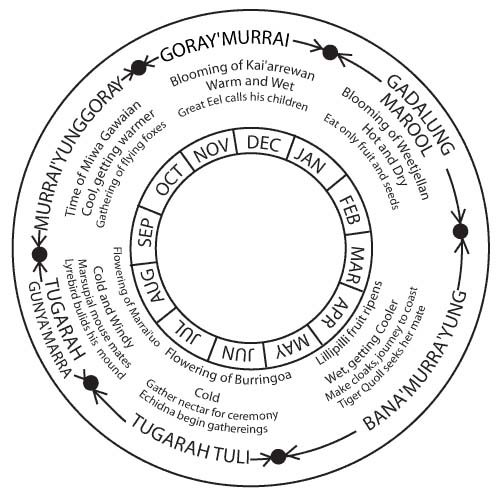

## Climate Change and Phenology

- **Shifts in climate can alter an organism’s phenology**
- **Insect and plant life cycles are connected**
  - e.g. flowering and insect emergence
- **What happens when species interactions become mismatched?**

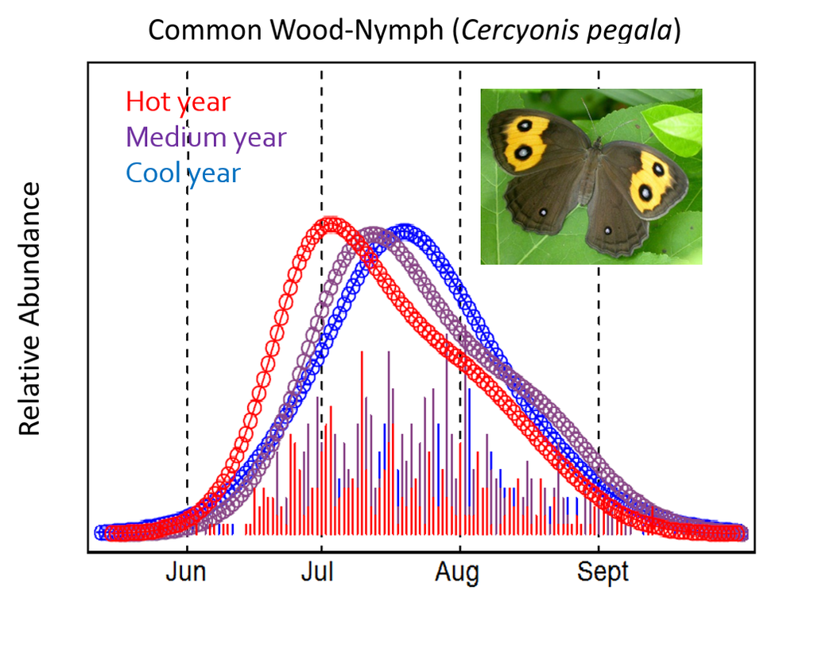

## Annual start of spring is shifting…

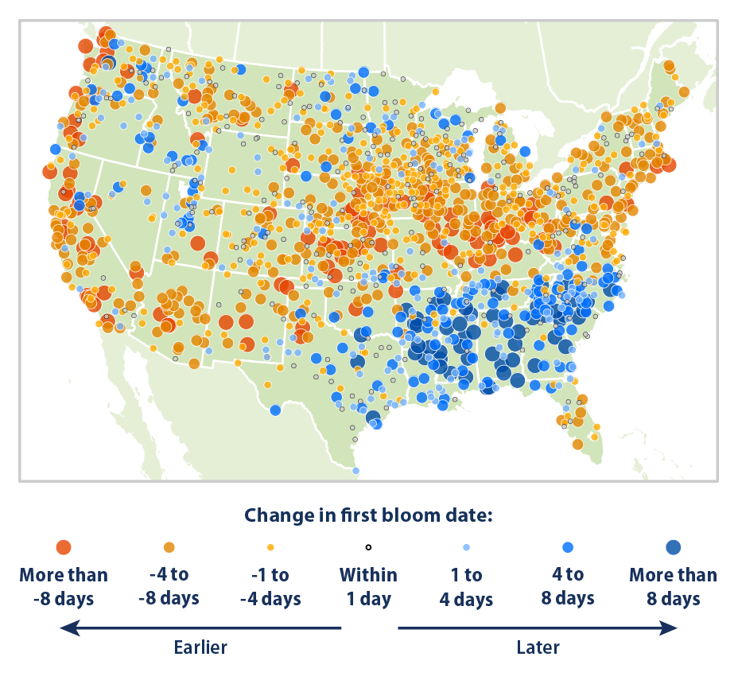

## Phenology from the plants perspective

**Question: Which is more important for plant reproduction and success?**

**Flowering time as a function of temperature changes**

**or**

**Timing of butterfly adult flights**

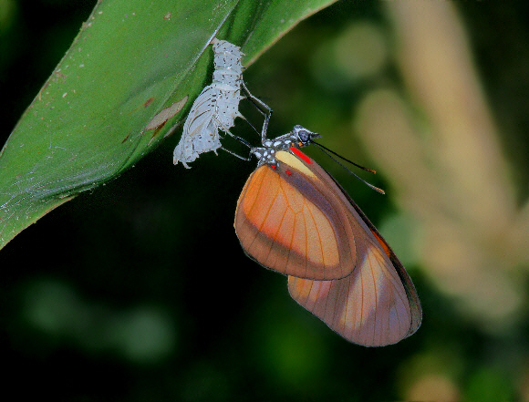

## Data: Modified from Kharouba and Vellend, 2015

- **Go to Brightspace > Open the excel file labeled “Phenology_student_data”**
  - Data Exercises module
- **Read the “Metadata” tab to understand what datasets you have available to explore**
- **Dataset: Temperature sensitivity of the timing of adult flight in butterflies in British Columbia, Canada.**
  - many butterfly species
  - observed day of first flight for many years
  - annual and seasonal climate data

## Understanding changes in butterfly phenology

- **Long term data from natural history specimens**
  - earliest collection date each year of specimens
  - proxy for phenology
  - online natural history database, iDigBio
- **First date an adult was collected signifies when the butterfly was in flight**
  - short lifespan of butterflies allows study of their phenology

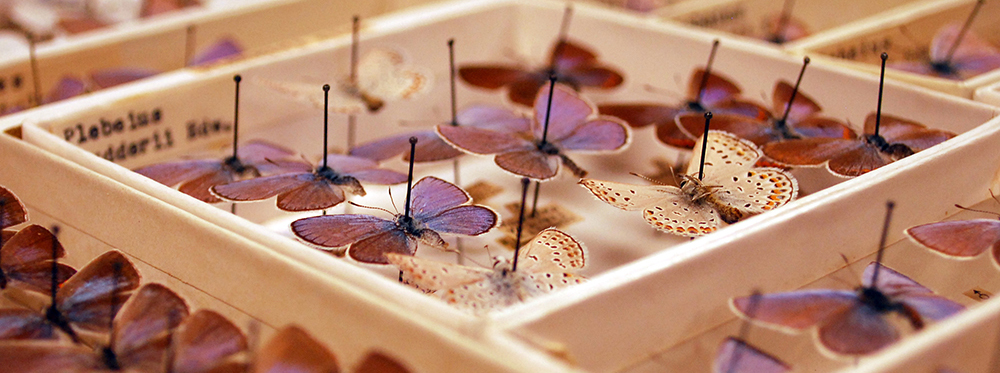